# Understanding Hotel Booking Behavior: A Data-Driven Analysis

## **Questions**

1. How do special requests and assigned room types influence guest satisfaction and stay duration?
2. How do lead time and booking cancellations impact revenue?
3. How does the country of origin influence booking behavior and lead time?
4. Does the presence of meal packages affect booking modifications or cancellations?
5. How do waiting list bookings and repeated guest status affect stay modifications and cancellations?

### **Q1. How do special requests and assigned room types influence guest satisfaction and stay duration?**

#### **Variables Used:**

- total_of_special_requests
- reserved_room_type
- assigned_room_type
- stay_duration (already created)
- is_canceled

#### **Step 1: Create a column to check if room types match**

```r
hotel_data <- hotel_data %>%
  mutate(room_match = if_else(reserved_room_type == assigned_room_type, "Matched", "Mismatched"))
```

#### **Step 2: Lineplot – Stay duration by number of special requests**

**Assumption**: More special requests suggest greater guest investment, likely leading to longer stays.

```r
# Avg stay duration for each number of special requests
stay_by_requests <- hotel_data %>%
  group_by(total_of_special_requests) %>%
  summarise(avg_stay = mean(stay_duration))

# View numeric output
print(stay_by_requests)
```

```
## # A tibble: 6 × 2
##   total_of_special_requests avg_stay
##                       <int>    <dbl>
## 1                         0     3.27
## 2                         1     3.59
## 3                         2     3.75
## 4                         3     3.98
## 5                         4     4.32
## 6                         5     4.65
```

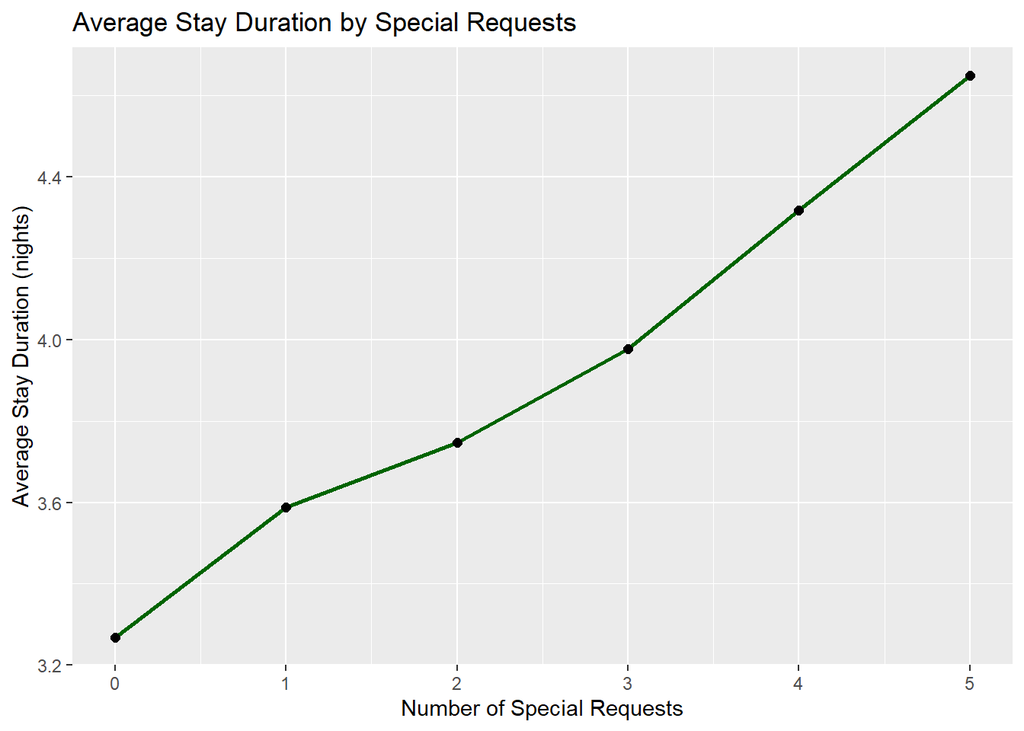

```r
# Plot: Line plot
ggplot(stay_by_requests, aes(x = total_of_special_requests, y = avg_stay)) +
  geom_line(color = "darkgreen", size = 1) +
  geom_point(size = 2) +
  labs(title = "Average Stay Duration by Special Requests",
       x = "Number of Special Requests",
       y = "Average Stay Duration (nights)")
```

**Result**: Stay duration increases from 3.27 nights (0 requests) to 4.65 nights (5 requests).

**Conclusion**: Assumption matched. More requests often indicate planned, meaningful stays.

#### **Step 3: Barchart – Stay duration by room match/mismatch**

**Assumption**: Matched rooms lead to better guest experience and longer stays.

```r
# Avg stay duration based on room match
stay_by_room <- hotel_data %>%
  group_by(room_match) %>%
  summarise(avg_stay = mean(stay_duration))

# View numeric output
print(stay_by_room)
```

```
## # A tibble: 2 × 2
##   room_match avg_stay
##   <chr>         <dbl>
## 1 Matched        3.52
## 2 Mismatched     2.77
```

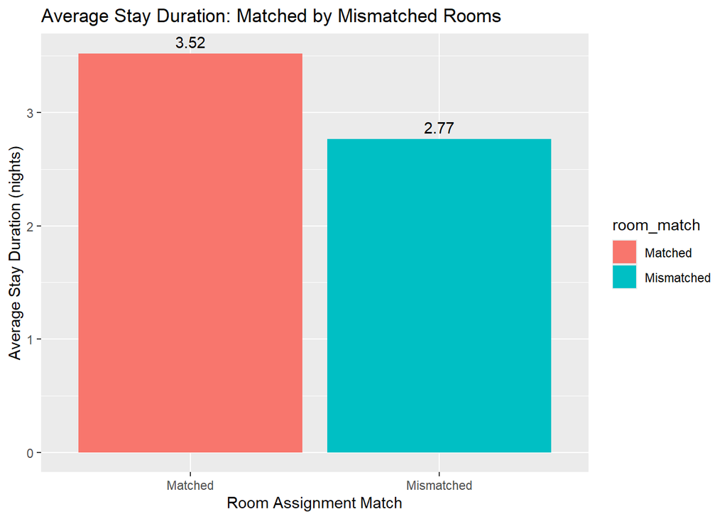

```r
# Plot: Bar chart
ggplot(stay_by_room, aes(x = room_match, y = avg_stay, fill = room_match)) +
  geom_bar(stat = "identity") +
  geom_text(aes(label = round(avg_stay, 2)), vjust = -0.5) +
  labs(title = "Average Stay Duration: Matched by Mismatched Rooms",
       x = "Room Assignment Match",
       y = "Average Stay Duration (nights)")
```

**Result**: Matched rooms = 3.52 nights; Mismatched = 2.77 nights.

**Conclusion**: Assumption matched. Receiving the booked room improves guest trust and experience.

#### **Step 4: Cancellation rate by special requests**

**Assumption**: Guests with more requests are less likely to cancel.

```r
# Calculate cancellation rate for each special request count
cancellation_by_requests <- hotel_data %>%
  group_by(total_of_special_requests) %>%
  summarise(cancel_rate = mean(is_canceled))

# View numeric output
print(cancellation_by_requests)
```

```
## # A tibble: 6 × 2
##   total_of_special_requests cancel_rate
##                       <int>       <dbl>
## 1                         0       0.477
## 2                         1       0.220
## 3                         2       0.221
## 4                         3       0.179
## 5                         4       0.106
## 6                         5       0.05
```

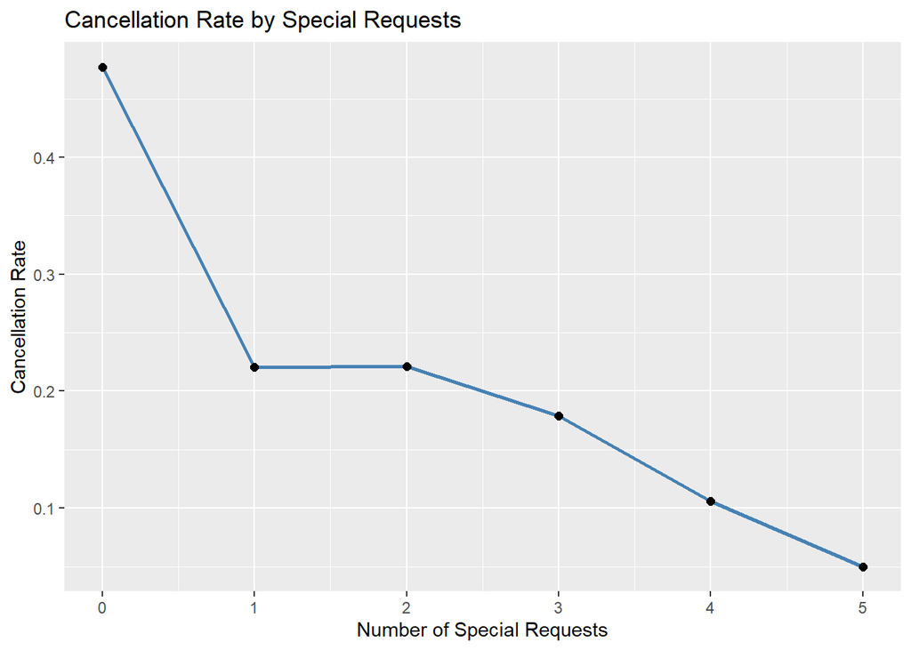

```r
# Plot: Bar chart
ggplot(cancellation_by_requests, aes(x = total_of_special_requests, y = cancel_rate)) +
  geom_line(color = "steelblue", size = 1) +
  geom_point(size = 2) +
  labs(title = "Cancellation Rate by Special Requests",
       x = "Number of Special Requests",
       y = "Cancellation Rate")
```

**Result**: Cancellation rate drops from 47.7% (0 requests) to 5% (5 requests).

**Conclusion**: Assumption matched. Special requests indicate higher commitment and reliability.

#### **Step 5: Does Room Matching Affect Cancellation Rates?**

**Assumption**: Mismatched rooms lead to higher cancellations.

```r
# Numeric output
hotel_data %>%
  group_by(room_match) %>%
  summarise(cancellation_rate = mean(is_canceled))
```

```
## # A tibble: 2 × 2
##   room_match cancellation_rate
##   <chr>                  <dbl>
## 1 Matched               0.416
## 2 Mismatched            0.0538
```

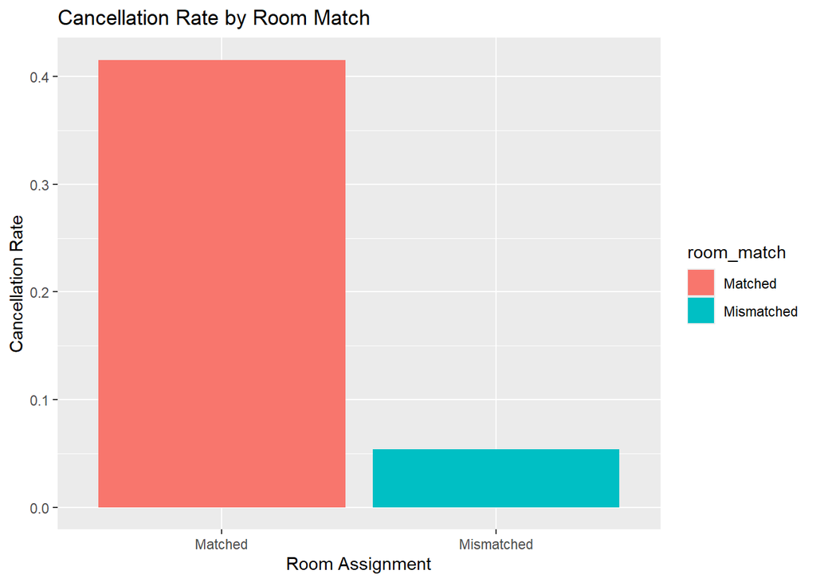

```r
# Bar chart (still helpful here)
ggplot(hotel_data %>%
         group_by(room_match) %>%
         summarise(cancellation_rate = mean(is_canceled)),
       aes(x = room_match, y = cancellation_rate, fill = room_match)) +
  geom_bar(stat = "identity") +
  labs(title = "Cancellation Rate by Room Match",
       x = "Room Assignment",
       y = "Cancellation Rate")
```

**Result**: Matched = 41.6%, Mismatched = 5.3%.

**Conclusion**: This is misleading—room match is known only after check-in. Mismatched rooms can’t exist for canceled bookings.

### **Q2. How does lead time and booking cancellations impact revenue?**

#### **Variables used:**

- lead_time
- is_canceled
- adr (Average Daily Rate)
- stay_duration (already created)
- revenue = adr * stay_duration

#### **Step 1: Bar Chart – Average Revenue by Cancellation Status**

**Assumption:** Canceled bookings bring in ₹0 revenue, while non-canceled bookings generate revenue.

```r
# Average revenue by cancellation status
avg_revenue <- hotel_data %>%
  filter(!is.na(revenue)) %>%
  group_by(is_canceled) %>%
  summarise(avg_rev = mean(revenue, na.rm = TRUE))

avg_revenue
```

```
## # A tibble: 2 × 2
##   is_canceled avg_rev
##         <int>   <dbl>
## 1           0    346.
## 2           1      0
```

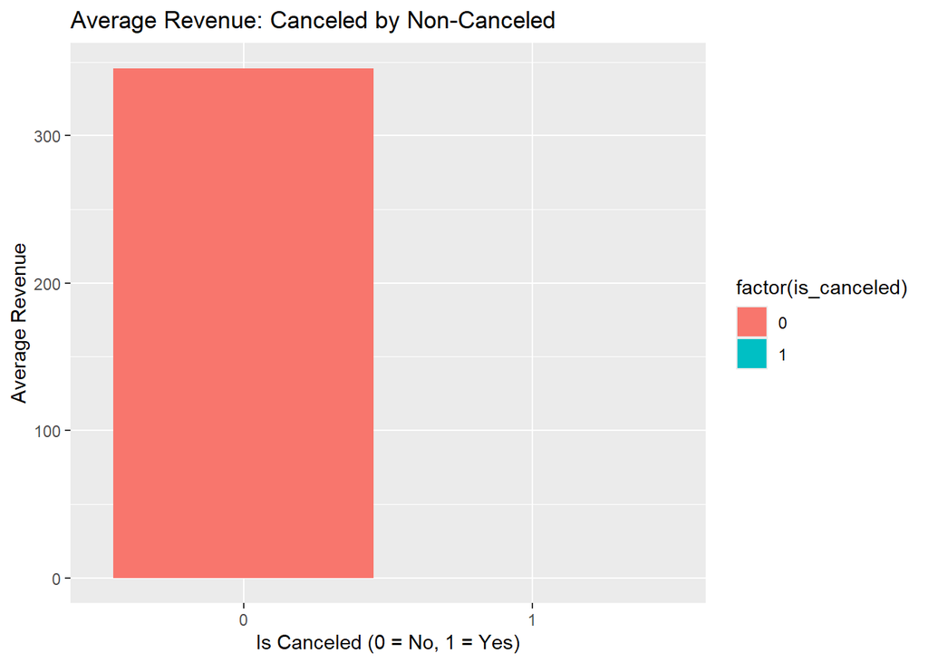

```r
ggplot(avg_revenue, aes(x = factor(is_canceled), y = avg_rev, fill = factor(is_canceled))) +
  geom_bar(stat = "identity") +
  labs(title = "Average Revenue: Canceled by Non-Canceled",
       x = "Is Canceled (0 = No, 1 = Yes)",
       y = "Average Revenue")
```

**Result:** Canceled bookings have ₹0 revenue, while non-canceled bookings generate an average of ₹346.

**Conclusion:** Assumption matched. And also, reducing cancellations can significantly improve overall hotel revenue.

#### **Step 2: Line plot — Lead Time by Cancellation Rate**

**Assumption:** The longer the lead time, the higher the chance of cancellation.

```r
cancel_by_lead <- hotel_data %>%
  mutate(lead_time_bin = cut(lead_time, breaks = seq(0, 500, 25))) %>%
  filter(!is.na(lead_time_bin)) %>%  # remove NAs created by cut()
  group_by(lead_time_bin) %>%
  summarise(cancellation_rate = mean(is_canceled, na.rm = TRUE))

cancel_by_lead
```

```
## # A tibble: 20 × 2
##    lead_time_bin cancellation_rate
##    <fct>                     <dbl>
##  1 (0,25]                    0.190
##  2 (25,50]                   0.355
##  3 (50,75]                   0.397
##  4 (75,100]                  0.410
##  5 (100,125]                 0.436
##  6 (125,150]                 0.448
##  7 (150,175]                 0.450
##  8 (175,200]                 0.470
##  9 (200,225]                 0.440
## 10 (225,250]                 0.538
## 11 (250,275]                 0.552
## 12 (275,300]                 0.651
## 13 (300,325]                 0.705
## 14 (325,350]                 0.663
## 15 (350,375]                 0.751
## 16 (375,400]                 0.547
## 17 (400,425]                 0.579
## 18 (425,450]                 0.828
## 19 (450,475]                 0.665
## 20 (475,500]                 0.739
```

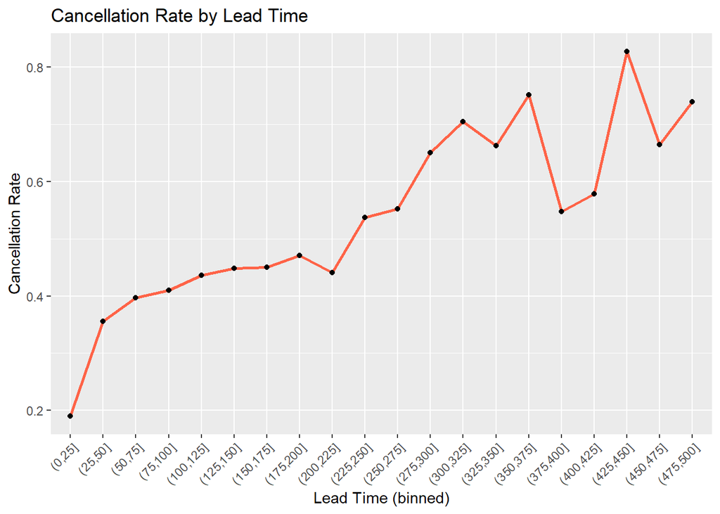

```r
ggplot(cancel_by_lead, aes(x = lead_time_bin, y = cancellation_rate, group = 1)) +
  geom_line(color = "tomato", size = 1) +
  geom_point() +
  theme(axis.text.x = element_text(angle = 45, hjust = 1)) +
  labs(title = "Cancellation Rate by Lead Time",
       x = "Lead Time (binned)",
       y = "Cancellation Rate")
```

**Conclusion:** Assumption matched. Longer lead times signal higher cancellation risk, so stricter policies could help reduce potential revenue loss.

#### **Step 3: Line plot — Lead Time by Average Revenue (only non-canceled)**

**Assumption:** Longer lead times may lead to lower revenue, while mid-range bookings could be more stable but less profitable.

```r
lead_rev <- hotel_data %>%
  filter(is_canceled == 0, !is.na(lead_time), !is.na(stay_duration), !is.na(adr)) %>%
  mutate(revenue = adr * stay_duration,
         lead_time_bin = cut(lead_time, breaks = seq(0, 500, 25))) %>%
  drop_na(lead_time_bin) %>%
  group_by(lead_time_bin) %>%
  summarise(avg_revenue = mean(revenue, na.rm = TRUE))

lead_rev
```

```
## # A tibble: 20 × 2
##    lead_time_bin avg_revenue
##    <fct>               <dbl>
##  1 (0,25]               258.
##  2 (25,50]              358.
##  3 (50,75]              380.
##  4 (75,100]             428.
##  5 (100,125]            447.
##  6 (125,150]            465.
##  7 (150,175]            495.
##  8 (175,200]            497.
##  9 (200,225]            451.
## 10 (225,250]            475.
## 11 (250,275]            395.
## 12 (275,300]            400.
## 13 (300,325]            441.
## 14 (325,350]            444.
## 15 (350,375]            455.
## 16 (375,400]            245.
## 17 (400,425]            270.
## 18 (425,450]            282.
## 19 (450,475]            282.
## 20 (475,500]            330.
```

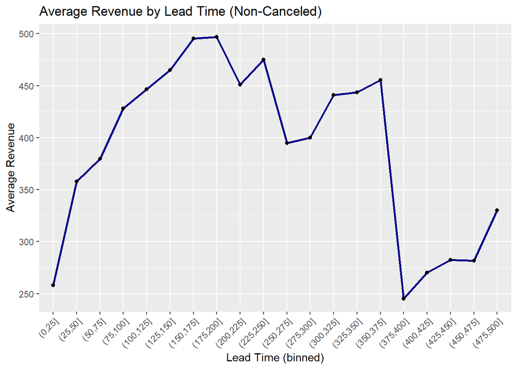

```r
ggplot(lead_rev, aes(x = lead_time_bin, y = avg_revenue, group = 1)) +
  geom_line(color = "darkblue", size = 1) +
  geom_point() +
  theme(axis.text.x = element_text(angle = 45, hjust = 1)) +
  labs(title = "Average Revenue by Lead Time (Non-Canceled)",
       x = "Lead Time (binned)",
       y = "Average Revenue")
```

**Result** Revenue peaks at 150–200 days (~₹490–₹500), then drops significantly after 375 days (to ₹245), with no clear cause found.

In order to find the cause for the sharp drop, I tried many different methods such as:

```r
#trying to analyze why the sudden drop in this last one

#assumption 1: maybe because of less sample size? NO
hotel_data %>%
  filter(is_canceled == 0,
         lead_time > 375, lead_time <= 400,
         !is.na(adr), !is.na(stay_duration)) %>%
  mutate(revenue = adr * stay_duration) %>%
  summarise(n = n(), mean_revenue = mean(revenue), min_revenue = min(revenue), max_revenue = max(revenue))
```

```
##     n mean_revenue min_revenue max_revenue
## 1 393     245.1728           0      1228.5
```

```r
#2. maybe because stay duration is less giving less adr? NOT QUITE
hotel_data %>%
  filter(is_canceled == 0,
         lead_time > 375, lead_time <= 400) %>%
  summarise(avg_stay = mean(stay_duration), avg_adr = mean(adr))
```

```
##   avg_stay  avg_adr
## 1 3.073791 88.08453
```

```r
#3. trying to figure out market segment- gives most TA/TO bookings
hotel_data %>%
  filter(is_canceled == 0, lead_time > 375, lead_time <= 400) %>%
  count(market_segment, distribution_channel) %>%
  arrange(desc(n))
```

```
##   market_segment distribution_channel   n
## 1  Offline TA/TO                TA/TO 256
## 2         Groups                TA/TO  69
## 3         Groups            Corporate  65
## 4  Complementary                TA/TO   1
## 5         Groups               Direct   1
## 6      Online TA                TA/TO   1
```

```r
#4. but no because this below one says that there were many others which had even higher TA TO booking
hotel_data %>%
  filter(is_canceled == 0, !is.na(lead_time)) %>%
  mutate(lead_time_bin = cut(lead_time, breaks = seq(0, 500, 25))) %>%
  filter(distribution_channel == "TA/TO") %>%
  count(lead_time_bin, sort = TRUE)
```

```
##    lead_time_bin     n
## 1         (0,25] 15906
## 2        (25,50]  8238
## 3        (50,75]  6176
## 4       (75,100]  4883
## 5      (100,125]  3901
## 6      (125,150]  3301
## 7      (150,175]  3113
## 8           <NA>  2508
## 9      (175,200]  2472
## 10     (200,225]  2031
## 11     (225,250]  1200
## 12     (250,275]  1183
## 13     (275,300]   774
## 14     (300,325]   654
## 15     (325,350]   402
## 16     (375,400]   327
## 17     (400,425]   278
## 18     (450,475]   162
## 19     (350,375]   112
## 20     (425,450]    60
## 21     (475,500]    37
```

```r
#5. Compare Booking Count & Revenue across Lead Time Bins
data<- hotel_data %>%
  filter(is_canceled == 0, !is.na(lead_time), !is.na(adr), !is.na(stay_duration)) %>%
  mutate(lead_time_bin = cut(lead_time, breaks = seq(0, 500, 25))) %>%
  group_by(lead_time_bin) %>%
  summarise(
    count = n(),
    avg_stay = mean(stay_duration, na.rm = TRUE),
    avg_adr = mean(adr, na.rm = TRUE),
    avg_revenue = mean(adr * stay_duration, na.rm = TRUE)
  ) %>%
  arrange(lead_time_bin)
data
```

```
## # A tibble: 21 × 5
##    lead_time_bin count avg_stay avg_adr avg_revenue
##    <fct>         <int>    <dbl>   <dbl>       <dbl>
##  1 (0,25]        23367     2.55    98.2        258.
##  2 (25,50]       10063     3.45   104.         358.
##  3 (50,75]        7102     3.66   104.         380.
##  4 (75,100]       5578     4.06   105.         428.
##  5 (100,125]      4537     4.23   106.         447.
##  6 (125,150]      3729     4.32   108.         465.
##  7 (150,175]      3643     4.69   106.         495.
##  8 (175,200]      2799     4.55   107.         497.
##  9 (200,225]      2354     4.56    99.1        451.
## 10 (225,250]      1322     5.11    94.1        475.
## # ℹ 11 more rows
```

**Conclusion:** The assumption partially holds, but the unexpected revenue drop after 375 days remains unexplained, marking a limitation in the analysis.

### **Q3. How does the country of origin influence booking behavior and lead time?**

#### **Variables used:**

- country
- lead_time
- is_canceled
- adr
- stay_duration
- revenue

To proceed, I first found out the top 10 countries from which the hotels get booking

```r
#Top 10 countries by booking count
top_countries <- hotel_data %>%
  filter(!is.na(country)) %>%
  count(country, sort = TRUE) %>%
  top_n(10, wt = n)

top_countries
```

```
##    country     n
## 1      PRT 48590
## 2      GBR 12129
## 3      FRA 10415
## 4      ESP  8568
## 5      DEU  7287
## 6      ITA  3766
## 7      IRL  3375
## 8      BEL  2342
## 9      BRA  2224
## 10     NLD  2104
```

#### **Step 1: Average lead time by country**

**Assumption:** International guests book earlier, resulting in longer lead times.

```r
lead_by_country <- hotel_data %>%
  filter(country %in% top_countries$country) %>%
  group_by(country) %>%
  summarise(avg_lead = mean(lead_time, na.rm = TRUE))

lead_by_country
```

```
## # A tibble: 10 × 2
##    country avg_lead
##    <chr>      <dbl>
##  1 BEL         99.7
##  2 BRA         83.3
##  3 DEU        137.
##  4 ESP         54.9
##  5 FRA         82.3
##  6 GBR        127.
##  7 IRL        120.
##  8 ITA         90.7
##  9 NLD         80.6
## 10 PRT        116.
```

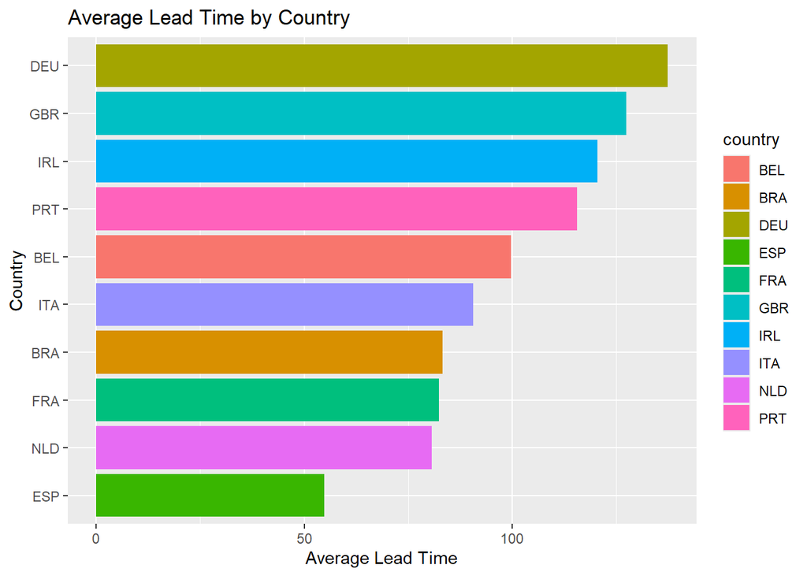

```r
ggplot(lead_by_country, aes(x = fct_reorder(country, avg_lead), y = avg_lead, fill = country)) +
  geom_bar(stat = "identity") +
  coord_flip() +
  labs(title = "Average Lead Time by Country", x = "Country", y = "Average Lead Time")
```

**Result** Germany, UK, and Ireland have the highest lead times (~120–137 days); Spain and Netherlands book much closer to the stay date (~55–80 days).

**Conclusion:** The assumption is supported — guests from farther countries plan earlier, while nearby countries tend to book more last-minute.

#### **Step 2: Cancellation rate by country**

**Assumption:** International guests cancel more often due to higher uncertainty.

```r
cancel_by_country <- hotel_data %>%
  filter(country %in% top_countries$country) %>%
  group_by(country) %>%
  summarise(cancellation_rate = mean(is_canceled, na.rm = TRUE))

cancel_by_country
```

```
## # A tibble: 10 × 2
##    country cancellation_rate
##    <chr>               <dbl>
##  1 BEL                 0.202
##  2 BRA                 0.373
##  3 DEU                 0.167
##  4 ESP                 0.254
##  5 FRA                 0.186
##  6 GBR                 0.202
##  7 IRL                 0.247
##  8 ITA                 0.354
##  9 NLD                 0.184
## 10 PRT                 0.566
```

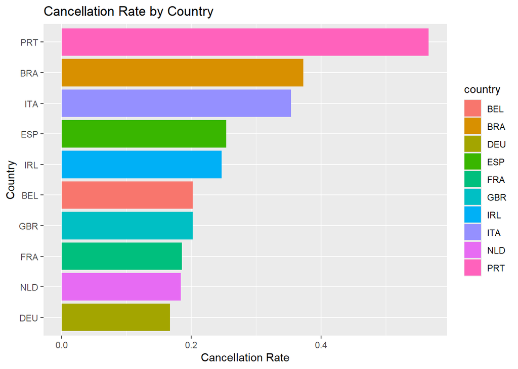

```r
ggplot(cancel_by_country, aes(x = fct_reorder(country, cancellation_rate), y = cancellation_rate, fill = country)) +
  geom_bar(stat = "identity") +
  coord_flip() +
  labs(title = "Cancellation Rate by Country", x = "Country", y = "Cancellation Rate")
```

**Result** Portugal (local) has the highest cancellation rate (~56.6%), while Germany, Netherlands, and France have much lower rates (~16–18%).

**Conclusion:** The assumption is not supported — local guests are more likely to cancel, possibly due to ease of booking and flexible policies.

#### **Step 3: Average special requests by country**

**Assumption:** Special request patterns vary by country due to cultural preferences or service expectations.

```r
requests_by_country <- hotel_data %>%
  filter(country %in% top_countries$country) %>%
  group_by(country) %>%
  summarise(avg_special_requests = mean(total_of_special_requests, na.rm = TRUE))

requests_by_country
```

```
## # A tibble: 10 × 2
##    country avg_special_requests
##    <chr>                  <dbl>
##  1 BEL                    0.875
##  2 BRA                    0.823
##  3 DEU                    0.645
##  4 ESP                    0.710
##  5 FRA                    0.727
##  6 GBR                    0.681
##  7 IRL                    0.779
##  8 ITA                    0.654
##  9 NLD                    0.797
## 10 PRT                    0.367
```

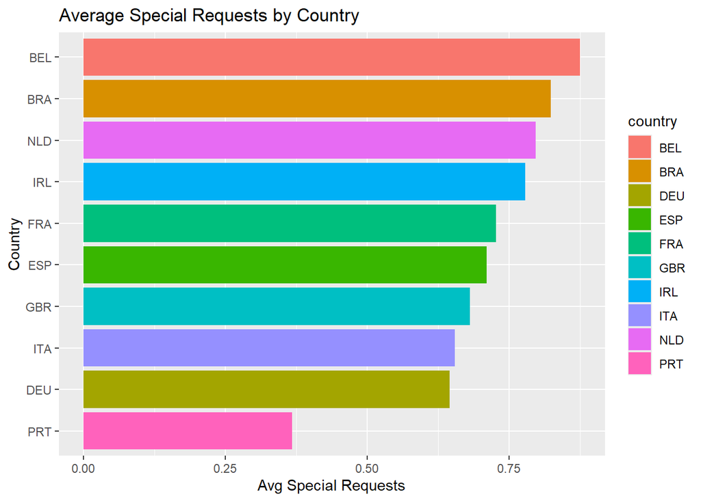

```r
ggplot(requests_by_country, aes(x = reorder(country, avg_special_requests), y = avg_special_requests, fill = country)) +
  geom_bar(stat = "identity") +
  coord_flip() +
  labs(title = "Average Special Requests by Country", x = "Country", y = "Avg Special Requests")
```

**Conclusion:** The assumption is supported — international guests tend to request more personalized services, possibly due to longer stays or differing hospitality expectations.

#### **Step 4: Average booking changes by country**

**Assumption:** Guests with complex or long-distance travel plans are more likely to modify bookings.

```r
changes_by_country <- hotel_data %>%
  filter(country %in% top_countries$country) %>%
  group_by(country) %>%
  summarise(avg_changes = mean(booking_changes, na.rm = TRUE))

changes_by_country
```

```
## # A tibble: 10 × 2
##    country avg_changes
##    <chr>         <dbl>
##  1 BEL           0.215
##  2 BRA           0.265
##  3 DEU           0.228
##  4 ESP           0.241
##  5 FRA           0.218
##  6 GBR           0.283
##  7 IRL           0.261
##  8 ITA           0.256
##  9 NLD           0.289
## 10 PRT           0.170
```

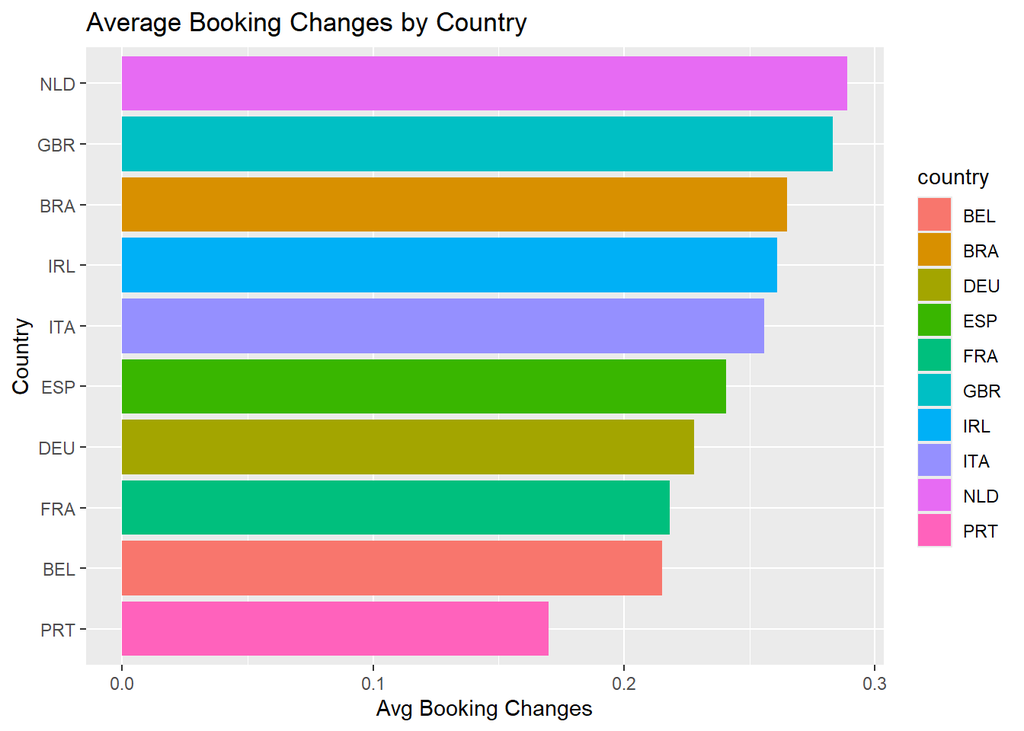

```r
ggplot(changes_by_country, aes(x = reorder(country, avg_changes), y = avg_changes, fill = country)) +
  geom_bar(stat = "identity") +
  coord_flip() +
  labs(title = "Average Booking Changes by Country", x = "Country", y = "Avg Booking Changes")
```

**Result:** Netherlands (0.289) and UK (0.283) had the highest average booking changes; Portugal had the lowest (0.170).

**Conclusion:** The assumption holds true — international guests modify bookings more, likely due to early planning and longer trips.

### **Q4. Does the presence of meal packages affect booking changes or cancellations?**

#### **Variables used:**

- meal
- is_canceled
- booking_changes

#### **Step 1: Calculate cancellation rate for each meal type**

**Assumption:** Guests with meal plans like Full Board are more committed and will cancel less.

```r
cancel_rate_meal <- hotel_data %>%
  group_by(meal) %>%
  summarise(
    total_bookings = n(),
    total_cancellations = sum(is_canceled),
    cancellation_rate = mean(is_canceled))

cancel_rate_meal
```

```
## # A tibble: 5 × 4
##   meal           total_bookings total_cancellations cancellation_rate
##   <chr>                   <int>               <int>             <dbl>
## 1 Breakfast Only          92310               34510             0.374
## 2 Full Board                798                 478             0.599
## 3 Half Board              14463                4984             0.345
## 4 No Meal                 10650                3966             0.372
## 5 Not Specified            1169                 286             0.245
```

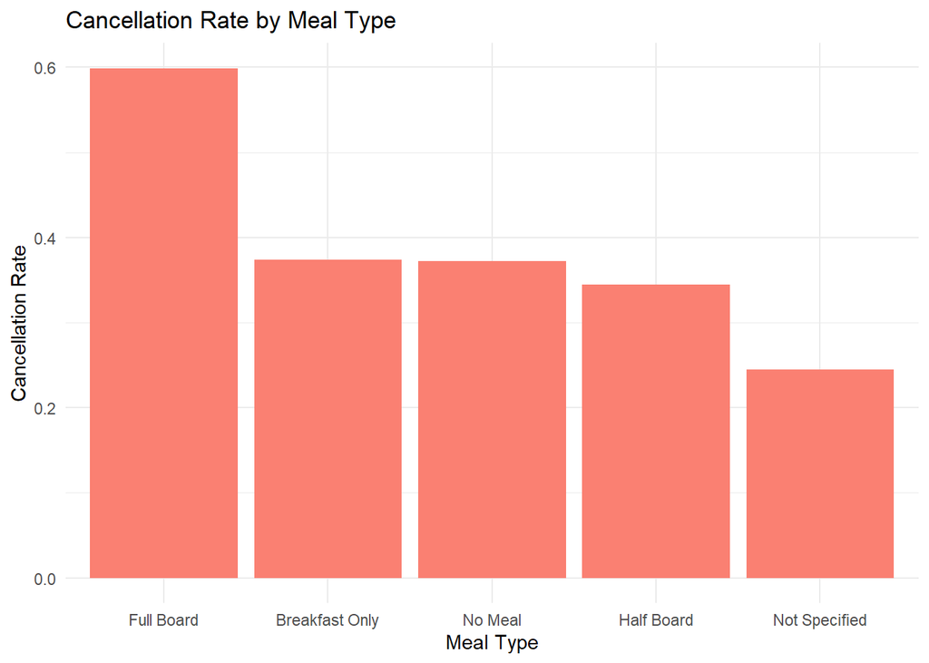

```r
# Bar chart: Cancellation Rate
ggplot(cancel_rate_meal, aes(x = reorder(meal, -cancellation_rate), y = cancellation_rate)) +
  geom_col(fill = "salmon") +
  labs(title = "Cancellation Rate by Meal Type",
       x = "Meal Type", y = "Cancellation Rate") +
  theme_minimal()
```

**Result:** Full Board guests had the highest cancellation rate (59.9%), while “Not Specified” had the lowest (24.5%).

**Conclusion:** The assumption doesn’t match the data — Full Board bookings may come from uncertain or bulk travel plans, leading to more cancellations.

#### **Step 2: Calculate average booking changes for each meal type**

**Assumption:** Guests with structured meal plans (like Full Board) will make more booking changes.

```r
# Calculate average booking changes for each meal type
booking_changes_meal <- hotel_data %>%
  group_by(meal) %>%
  summarise(
    avg_changes = mean(booking_changes, na.rm = TRUE))

booking_changes_meal
```

```
## # A tibble: 5 × 2
##   meal           avg_changes
##   <chr>                <dbl>
## 1 Breakfast Only       0.209
## 2 Full Board           0.302
## 3 Half Board           0.320
## 4 No Meal              0.172
## 5 Not Specified        0.369
```

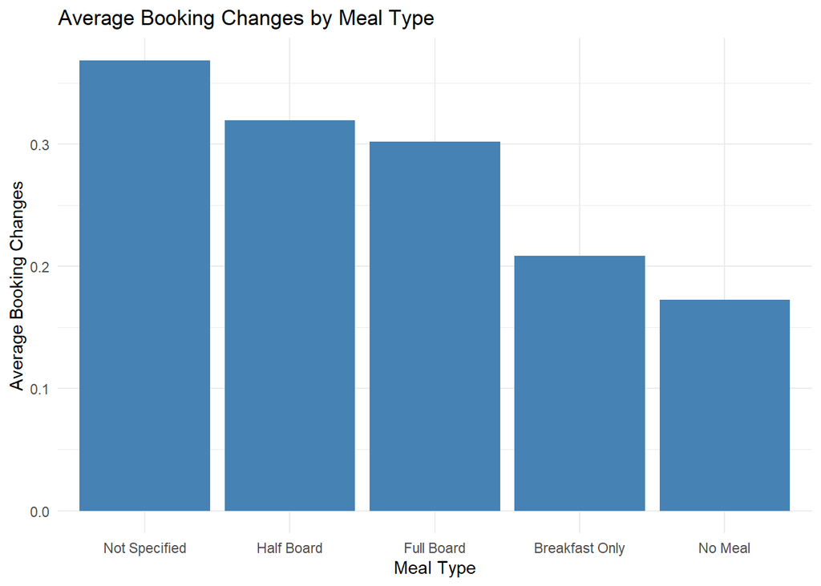

```r
# Bar chart: Average Booking Changes
ggplot(booking_changes_meal, aes(x = reorder(meal, -avg_changes), y = avg_changes)) +
  geom_col(fill = "steelblue") +
  labs(title = "Average Booking Changes by Meal Type",
       x = "Meal Type", y = "Average Booking Changes") +
  theme_minimal()
```

**Result:** Guests with “Not Specified” meals made the most changes (0.369); “No Meal” guests made the fewest (0.172).

**Conclusion:** The assumption matches the insights — more structured or early bookings lead to more changes, while simple stays involve fewer modifications.

#### **Step 3: Count of bookings for each meal type**

**Assumption:** N/A (exploratory analysis to understand booking volumes).

```r
# Count of bookings for each meal type
meal_counts <- hotel_data %>%
  count(meal)
meal_counts
```

```
##             meal     n
## 1 Breakfast Only 92310
## 2     Full Board   798
## 3     Half Board 14463
## 4        No Meal 10650
## 5  Not Specified  1169
```

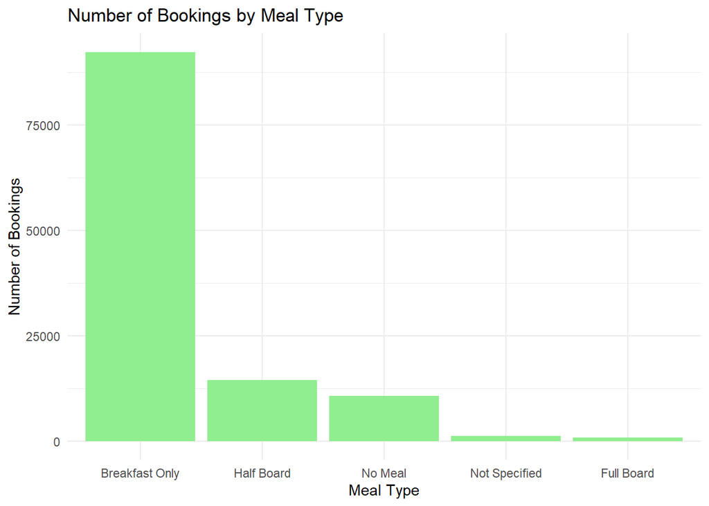

```r
# Bar chart: Number of Bookings
ggplot(meal_counts, aes(x = reorder(meal, -n), y = n)) +
  geom_col(fill = "lightgreen") +
  labs(title = "Number of Bookings by Meal Type",
       x = "Meal Type", y = "Number of Bookings") +
  theme_minimal()
```

**Result:** “Breakfast Only” is the most popular meal type with 92,310 bookings; “Full Board” is the least popular with just 798 bookings.

**Conclusion:** Breakfast-inclusive plans are the most preferred, likely due to affordability and flexibility, while Full Board appeals to a smaller segment seeking all-inclusive experiences.

### **Q5. How do waiting list bookings and repeated guest status affect stay modifications and cancellations?**

#### **Variables Used:**

- is_repeated_guest
- is_canceled
- booking_changes
- days_in_waiting_list
- waitlist_status – “Waitlisted” : if days_in_waiting_list > 0 – “Not Waitlisted”: otherwise

#### **Step 1: Cancellation Rate by Repeated Guest Status**

**Assumption:** Repeated guests are more committed and less likely to cancel.

```r
cancel_repeated <- hotel_data %>%
  group_by(is_repeated_guest) %>%
  summarise(cancellation_rate = mean(is_canceled, na.rm = TRUE))

cancel_repeated
```

```
## # A tibble: 2 × 2
##   is_repeated_guest cancellation_rate
##               <int>             <dbl>
## 1                 0             0.378
## 2                 1             0.145
```

**Result:** New guests canceled at a rate of 37.8%, while repeated guests canceled only 14.5%.

**Conclusion:** The assumption is confirmed — repeated guests show stronger booking commitment, making them a valuable and more reliable customer segment.

#### **Step 2: Booking Changes by Repeated Guest Status**

**Assumption:** Repeated guests make fewer booking changes due to confidence and familiarity.

```r
changes_repeated <- hotel_data %>%
  group_by(is_repeated_guest) %>%
  summarise(avg_changes = mean(booking_changes, na.rm = TRUE))

changes_repeated
```

```
## # A tibble: 2 × 2
##   is_repeated_guest avg_changes
##               <int>       <dbl>
## 1                 0       0.220
## 2                 1       0.265
```

**Result:** Repeated guests actually made more changes (0.265 vs. 0.220).

**Conclusion:** The assumption is contradicted — familiarity may encourage repeated guests to modify bookings more freely, reflecting trust and flexibility rather than uncertainty.

#### **Step 3: Cancellation Rate by Waitlist Status**

Before going to answering the question, I created a waitlist category first:

```r
# Create Waitlist Category
hotel_data <- hotel_data %>%
  mutate(waitlist_status = ifelse(days_in_waiting_list > 0, "Waitlisted", "Not Waitlisted"))
```

**Assumption:** Waitlisted guests are more likely to cancel due to uncertainty.

```r
cancel_summary <- hotel_data %>%
  group_by(waitlist_status) %>%
  summarise(value = mean(is_canceled)) %>%
  mutate(metric = "Cancellation Rate")

cancel_summary
```

```
## # A tibble: 2 × 3
##   waitlist_status value metric
##   <chr>           <dbl> <chr>
## 1 Not Waitlisted  0.362 Cancellation Rate
## 2 Waitlisted      0.638 Cancellation Rate
```

**Result:** Cancellation rate is significantly higher for waitlisted guests (63.8% vs. 36.2%).

**Conclusion:** Assumption holds true — waitlisting increases cancellation risk, highlighting the need for faster confirmations or better communication to retain these bookings.

#### **Step 4: Booking Changes by Waitlist Status**

**Assumption:** Waitlisted guests are less likely to modify bookings due to uncertainty or inclination to cancel.

```r
change_summary <- hotel_data %>%
  group_by(waitlist_status) %>%
  summarise(value = mean(booking_changes)) %>%
  mutate(metric = "Booking Changes")

change_summary
```

```
## # A tibble: 2 × 3
##   waitlist_status value metric
##   <chr>           <dbl> <chr>
## 1 Not Waitlisted  0.223 Booking Changes
## 2 Waitlisted      0.159 Booking Changes
```

**Result:** Waitlisted guests have fewer booking changes (0.159 vs. 0.223).

**Conclusion:** Assumption matches the result— uncertainty among waitlisted guests results in fewer modifications and more cancellations.

#### **Step 5: Combined plot for all steps above**

```r
#combining all summaries
combined_summary <- bind_rows(cancel_summary, change_summary)
combined_summary
```

```
## # A tibble: 4 × 3
##   waitlist_status value metric
##   <chr>           <dbl> <chr>
## 1 Not Waitlisted  0.362 Cancellation Rate
## 2 Waitlisted      0.638 Cancellation Rate
## 3 Not Waitlisted  0.223 Booking Changes
## 4 Waitlisted      0.159 Booking Changes
```

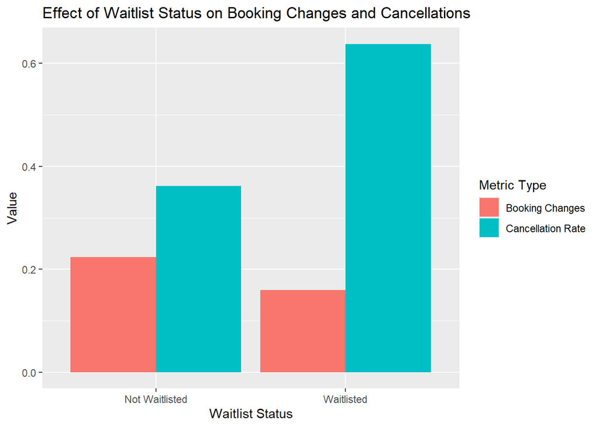

```r
#Combined Plot
ggplot(combined_summary, aes(x = waitlist_status, y = value, fill = metric)) +
  geom_bar(stat = "identity", position = "dodge") +
  labs(title = "Effect of Waitlist Status on Booking Changes and Cancellations",
       x = "Waitlist Status", y = "Value", fill = "Metric Type")
```

## **Results**

#### **Q1: Special Requests & Room Match Impact**

- Stay duration increases with more special requests (from 3.27 to 4.65 nights).
- Guests with matched rooms stay longer (3.52 nights) than those with mismatched rooms (2.77 nights).
- Cancellation rate drops sharply as special requests increase — from 47.7% to just 5%.
- Room mismatch does not increase cancellations (matched: 41.6%, mismatched: only 5.3%).

#### **Q4: Meal Type Insights**

- Full Board guests cancel most (59.9%); “Not Specified” cancel least (24.5%).
- Most booking changes come from “Not Specified” meal types (0.369); least from “No Meal” (0.172).
- “Breakfast Only” is the most popular meal plan (92,310 bookings); “Full Board” the least popular (798 bookings).

#### **Q5: Guest Type & Waitlist Behavior**

- Repeated guests cancel less (14.5%) than new guests (37.8%).
- Repeated guests make more changes (0.265 vs 0.220).
- Waitlisted guests cancel more (63.8% vs 36.2%).
- Waitlisted guests make fewer changes (0.159 vs 0.223).

## **Conclusion**

#### **Q1:**

- Guests who make more special requests usually stay longer and are much less likely to cancel their bookings, which shows they are more committed and satisfied.
- Also, people who get the same room type they booked tend to stay a bit longer, likely because they feel their expectations were met.
- However, the data on room mismatches and cancellations is tricky—since cancellations happen before rooms are assigned, we can’t say mismatched rooms cause fewer cancellations.
- Overall, special requests are a strong sign of guest satisfaction, and giving people what they ask for can lead to better experiences and fewer cancellations.

#### **Q2:**

- Guest behavior around cancellations is strongly influenced by how early they book — longer lead times are linked with much higher cancellation rates.
- Canceled bookings bring in no revenue, while non-canceled ones contribute significantly.
- Interestingly, revenue doesn’t always drop with longer lead times, though one specific drop couldn’t be fully explained, marking a limitation.
- These insights can help hotels tailor strategies to reduce cancellations and maximize revenue.

#### **Q4:**

Overall, meal type plays an interesting role in guest behavior.

- Guests with “Not Specified” or structured meal plans tend to make more booking changes, possibly because they book earlier or as part of tour packages.
- However, contrary to expectations, Full Board bookings had the highest cancellation rate, suggesting that these high-commitment bookings may also carry more uncertainty.
- In terms of popularity, “Breakfast Only” dominates, likely due to its affordability and flexibility, while Full Board remains a niche choice.
- These insights can help hotels design meal plans and policies that match guest preferences and booking patterns.

#### **Q5:**

- Waitlisted guests show distinct behavior — they cancel much more frequently (63.8% vs 36.2%) and make fewer booking changes (0.159 vs 0.223). This suggests that uncertainty in reservation confirmation leads them to either cancel outright or avoid modifying bookings.
- In contrast, non-waitlisted guests are more stable in their plans, showing lower cancellation rates and a higher willingness to update their bookings.
- Addressing waitlist uncertainty quickly could help reduce cancellations and improve engagement.

## **References**

- Mostipak, Jesse. *Hotel Booking Demand*. Kaggle, 2018, https://www.kaggle.com/datasets/jessemostipak/hotel-booking-demand.
- “ggplot2.” *The Tidyverse*, https://ggplot2.tidyverse.org/. (documentation)
- “dplyr.” *The Tidyverse*, https://dplyr.tidyverse.org/. (documentation)
- Teaching Notes on Canvas
- Grolemund, Garrett, and Hadley Wickham. *R for Data Science*. O’Reilly Media, 2018.

## **Appendix**

**A. Variable names and meaning in the dataset:**

hotel – Type of hotel (e.g., Resort Hotel or City Hotel)

is_canceled – 1 if the booking was canceled, 0 if not

lead_time – Number of days between the booking date and the arrival date

arrival_date_year – Year of arrival

arrival_date_month – Month of arrival

arrival_date_week_number – Week number of the arrival date

arrival_date_day_of_month – Day of the month for arrival

stays_in_weekend_nights – Number of weekend nights (Saturday or Sunday)

stays_in_week_nights – Number of weekday nights (Monday–Friday)

adults – Number of adults

children – Number of children

babies – Number of babies

meal – Type of meal (BB, HB, FB)

country – Country of origin of the guest

market_segment – Market segment that made the booking (Direct, Corporate, Online TA, etc.)

distribution_channel – Distribution channel (Direct, TA/TO, etc.)

is_repeated_guest – 1 if a repeated guest, 0 otherwise

previous_cancellations – Number of previous cancellations

previous_bookings_not_canceled – Number of previous bookings that were not canceled

reserved_room_type – Code of the reserved room type

assigned_room_type – Code of the assigned room type

booking_changes – Number of changes made to the booking

deposit_type – Type of deposit (No Deposit, Non Refund, etc.)

agent – ID of the travel agent that made the booking

company – ID of the company that made the booking

days_in_waiting_list – Number of days the booking was on the waiting list

customer_type – Type of customer (Transient, Group, etc.)

adr – Average Daily Rate (ADR), i.e., revenue per available room

required_car_parking_spaces – Number of required parking spaces

total_of_special_requests – Number of special requests made by the guest

reservation_status – Status of the reservation (Check-Out, Canceled, etc.)

reservation_status_date – Date when the last status was updated

**B. Countries in this report are in the ISO code. Below is what each top 10 country ISO stands for:** PRT -> Portugal

GBR -> United Kingdom

FRA -> France

ESP -> Spain

DEU -> Germany

ITA -> Italy

IRL -> Ireland

BEL -> Belgium

BRA -> Brazil

NLD -> Netherlands